# Préparation CCF E5.2 : SAEIV

Ce système sera utilisé dans le cadre de l’épreuve de CCF E5.2 qui se déroulera courant janvier 2017.

## Présentation

Les transports en commun se modernisent. Régis par l’arrêté du 3 Mai 2007, les bus mis en circulation doivent disposer d’un système d’informations voyageurs (SIV) sonores et visuelles.

La gestion et la diffusion des informations sont gérées par un calculateur embarqué. A l’intérieur du bus, un haut parleur annonce le numéro de la ligne, la destination, le nom de l’arrêt en cours et le suivant. Ces informations sont reprises par un affichage sur écran et un bandeau lumineux.

Le calculateur, associé à un système de géolocalisation et de communication, permet également de répondre à une double attente à savoir l’amélioration de l’information donnée aux usagers, et la régulation du trafic en temps réel par l’exploitant.

**On dispose d’un système capable d’améliorer l’information donnée aux usagers à l’intérieur des bus, et d’aider à la régulation du trafic en temps réel par l’exploitant.**

Pour cela, le système doit :

- localiser géographiquement les bus et les arrêts ;
- assurer la communication entre les bus et le poste de commande central (PCC) ;
- informer de manière sonore et visuelle les voyageurs dans le bus ;
- aider à la régulation du trafic en temps réel.

Le système comprend les sous-systèmes suivants :

- Système d’Aide à l’Exploitation (SAE) ;
- Système d’Aide à l’Information (SAI) ;
- Système d’Informations Voyageurs (SIV).

Le Système d’Aide à l’Exploitation (SAE) désigne globalement un SAE Temps Différé (SAE-TD) et le Système d’Aide à l’Information (SAI) un SAE Temps réel (SAE-TR). Ce sont des systèmes informatiques implantés au Poste de Commande Centralisé (PCC), en liaison avec les Systèmes d’Informations Voyageurs (SIV-BERRY) des bus.

Le SAE assiste les opérateurs du PCC (exploitants) dans ses principales missions d’exploitation du réseau de bus. Les fonctionnalités principales du SAE sont l’élaboration du référentiel et le transfert des données du référentiel.

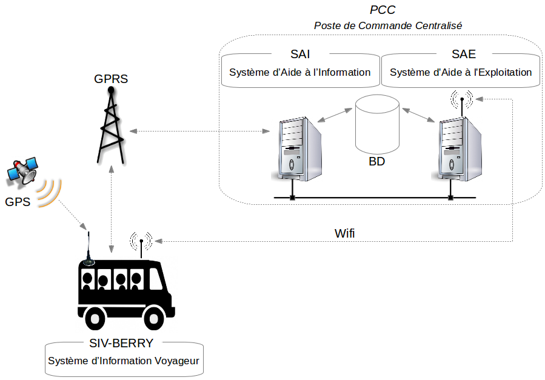

Le système met en oeuvre différents périphériques nécessaires à l’information des voyageurs à l’intérieur du bus. Il se compose d’un Système Embarqué (SE, ici un nano ordinateur Raspberry Pi), d’un système de communication (GPS/GPRS/Wifi), d’un pupitre pour le conducteur, d’un écran vidéo pour les usagers, d’un équipement audio et d’un bandeau lumineux à LED.

[figure not shown]

Le référentiel est un ensemble de données descriptives de l’exploitation du réseau (référentiel SAE). Ces données concernent :

- la description de la topologie du réseau : lignes, arrêts, chaînages des tronçons, etc.
- la description des horaires : calendriers, services matériels etc.
- la description des ressources : conducteurs, véhicules etc.

Ces données sont mémorisées dans la BD (base de données) du PCC, et mises à disposition des différents sous-systèmes en fonction de leurs besoins.

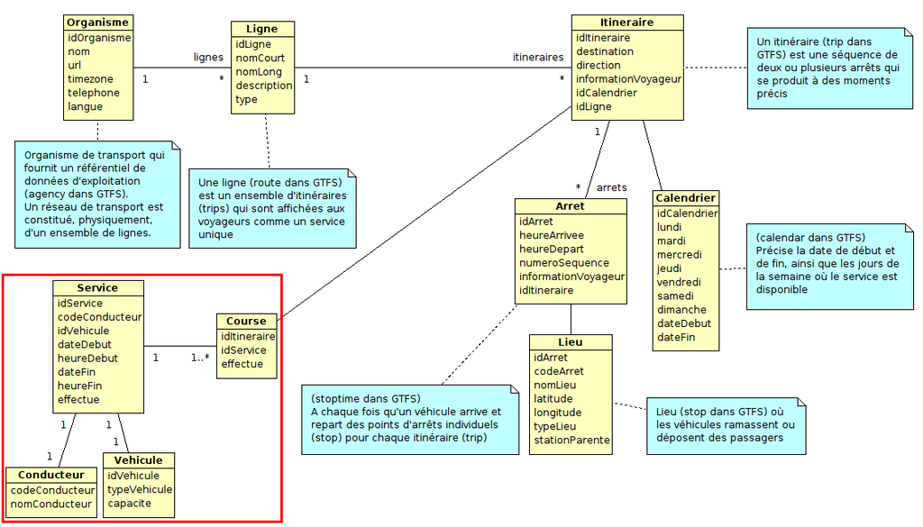

Le SAE (SAE-TD) assure la fonction de transfert des données du référentiel :

- vers le SAI (SAE-TR) : données nécessaires à la journée d’exploitation suivantes transférées par réseau au SAE-TR (automatiquement ou manuellement) chaque jour avant l’heure de début d’exploitation ;
- vers les SIV-BERRY de chaque bus : données descriptives de la topologie et des horaires de la journée, préparées et transférées par Wifi (automatiquement ou manuellement) tous les soirs.

Le Système d’Aide à l’Information (SAI) assiste le régulateur pour qu’il puisse suivre sur un écran la position des bus sur le réseau, ligne par ligne et prendre des décisions de contrôle de trafic. Il pourra ainsi visualiser l’avance ou le retard des bus.

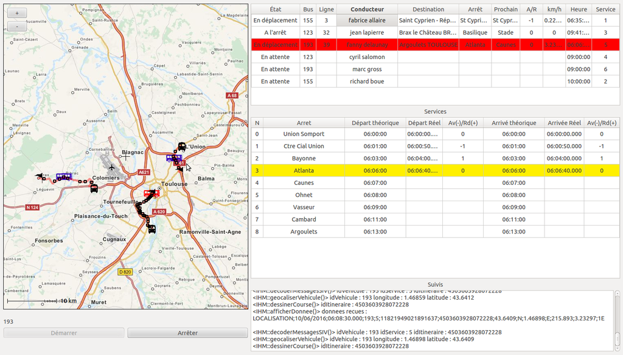

## Contraintes d’environnement

| Ressource | Version |
| --- | --- |
| OS | GNU Linux (Ubuntu 12.04.5 LTS) |
| EDI | Qt Creator 2.4.1 |
| Compilateur | GNU g++/gcc version 4.6.3 |
| Débugueur | GNU gdb 7.4 |
| Fabrication | QMake 2.01a et GNU make 3.81 |
| API GUI | Qt 4.8.1 |

## SAE

Avant d’utiliser le système SAEIV, il vous faut générer les référentiels à partir de l’application SAE.

## SAI

Il est possible de superviser l’ensemble des SIV sur le réseau à partir de l’application SAI.

## Manuel d’installation SIV

0. Exécuter le programme d’installation setup-siv-rpi.sh :

```
$ sudo ./setup-siv-rpi.sh
```

Ou exécuter le programme d’installation setup-siv.sh pour PC :

```
$ sudo ./setup-siv.sh
```

1. Cablage des périphériques du SIV

[figure not shown]

2. Vérifier les droits aux périphériques USB de façon automatique

```
$ sudo vim /etc/udev/rules.d/51-ttyusb.rules

SUBSYSTEMS=="usb", ATTRS{idVendor}=="067b", ATTRS{idProduct}=="2303", MODE="0666", SYMLINK+="qtp"
SUBSYSTEMS=="usb", ATTRS{idVendor}=="0557", ATTRS{idProduct}=="2008", MODE="0666", SYMLINK+="panneau"
SUBSYSTEMS=="usb", ATTRS{idVendor}=="05c6", ATTRS{idProduct}=="9000", MODE="0666", SYMLINK+="gps"
```

Brancher les périphériques et vérifier la détection :

```
$ ll /dev/ | grep ttyUSB
lrwxrwxrwx  1 root root             7 avril 21 09:50 gps -> ttyUSB2
lrwxrwxrwx  1 root root             7 avril 21 09:50 panneau -> ttyUSB1
lrwxrwxrwx  1 root root             7 avril 21 09:50 qtp -> ttyUSB0
crw-rw-rw-  1 root dialout   188,   0 avril 21 09:51 ttyUSB0
crw-rw-rw-  1 root dialout   188,   1 avril 21 09:52 ttyUSB1
crw-rw-rw-  1 root dialout   188,   2 avril 21 09:52 ttyUSB2
```

3. Paramétrer l’application siv

L’application gère ses paramètres de configuration à partir d’un fichier `siv.ini` :

[output not shown]

*Remarque :* il vous faudra au moins configurer l’adresse IP du serveur SAI. Le fichier `siv.ini` est stocké dans `/usr/share/siv/`.

Le référentiel du SIV est stocké dans le répertoire `/usr/share/siv/referentiel` et porte le nom `prefixe-<numeros-bus>.sqlite` :

```
$ ls -l /usr/share/siv/referentiel/
-rw------- 1 root root 262144 juin   9 18:20 referentiel-123.sqlite
```

4. Démarrer le SIV

```
$ siv
```

*Remarque :* L’installateur a assuré la prise en charge du lancement automatique de l’application au démarrage de la Raspberry Pi. Vous pouvez vérifier en réalisant un reboot. Si votre système ne démarre pas automatiquement l’interface graphique, il vous faudra le configurer en exécutant la commande `sudo raspi-config` :

```
Raspberry Pi Software Configuration Tool (raspi-config)

Setup Options

1 Expand Filesystem              Ensures that all of the SD card storage is available to the OS
2 Change User Password           Change password for the default user (pi)
-> 3 Enable Boot to Desktop/Scratch Choose whether to boot into a desktop environment, Scratch, or the command-line
4 Internationalisation Options   Set up language and regional settings to match your location
5 Enable Camera                  Enable this Pi to work with the Raspberry Pi Camera
6 Add to Rastrack                Add this Pi to the online Raspberry Pi Map (Rastrack)
7 Overclock                      Configure overclocking for your Pi
8 Advanced Options               Configure advanced settings
9 About raspi-config             Information about this configuration tool

Chose boot option

Console Text console, requiring login (default)
-> Desktop Log in as user 'pi' at the graphical desktop
Scratch Start the Scratch programming environment upon boot
```

Vous pouvez utiliser le simulateur de GPS pour tester le système. Dans ce cas, débrancher le module GPS/GPRS sim 5218 et brancher deux adapteurs RS232/USB et un cable série :

[figure not shown]

**Attention :** Vérifier la prise en charge des périphériques et contrôler votre fichier de configuration `siv.ini`.

## Manuel d’utilisation SIV

[figure not shown]

*Remarque :* vous pouvez quitter l’application avec la touche 5. Les touches A, B, C, D permettent d’envoyer des messages d’alerte au SAI.

Exemple en mode simulation sur PC :

```
1. PRISE DE SERVICE
2. FIN DE SERVICE
3. DEMARRER COURSE
4. AFFICHER COURSE
1
*                  *
  PRISE DE SERVICE
     SAISIR CODE

1993#
*                  *
      SERVICE
        OK

1. PRISE DE SERVICE
2. FIN DE SERVICE
3. DEMARRER COURSE
4. AFFICHER COURSE
3
*                  *
      COURSE
     DEMARRER

En attente ...



LIGNE : 32     14:52
Colomiers Gare SNCF
La Chauge
Depart : 07:14:00

LIGNE : 32     14:53
Colomiers Gare SNCF
Chateau Cru
Depart : 07:16:00
5
```

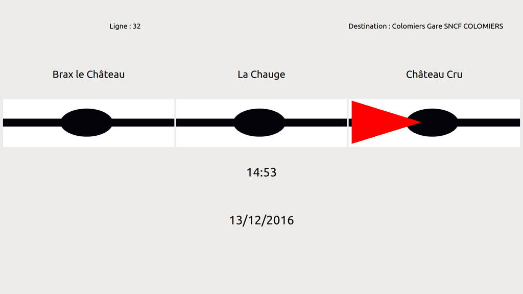

## Glossaire

- SAE (Système d’Aide à l’Exploitation) : il assiste les opérateurs du PCC (exploitants) dans ses principales missions d’exploitation du réseau de bus. Les fonctionnalités principales du SAE sont l’élaboration du référentiel et le transfert des données du référentiel.
- SAI (Système d’Aide à l’Information) : il assiste le régulateur pour qu’il puisse suivre sur un écran la position des bus sur le réseau, ligne par ligne et prendre des décisions de contrôle de trafic. Il pourra ainsi visualiser l’avance ou le retard des bus.
- SIV (Système d’Informations Voyageurs) : c’est une installation présente dans le véhicule de transport en commun permettant, de manière automatique, d’informer les voyageurs visuellement et par un dispositif sonore à propos du trajet (arrivée à un arrêt, liste des arrêts, destination …).
- PCC (Poste de Commande Centralisé) : il regroupe le SAE, SAI et la base de données contenant le référentiel du réseau de transport.
- Référentiel : c’est un ensemble de données descriptives de l’exploitation du réseau : topologie du réseau (lignes, arrêts, chaînages des tronçons, etc.), description des horaires (calendriers, services matériels etc.) et description des ressources (conducteurs, véhicules etc.). Ces données sont mémorisées dans la BD (base de données) du PCC, et mises à disposition des différents sous-systèmes en fonction de leurs besoins.

## Activités

- Matériels : Pupitre conducteur QTP16, Bandeau lumineux, GPS/GPRS et Raspberry Pi
- Interfaces de communication : Périphérique USB
- Bus de terrain : aucun
- Réseau : aucun
- Fichiers : LOG, INI et Base de données
- Autre(s) : PHP

Liste :

- Les fichiers LOG : 3h
- Les fichiers INI : 3h
- Base de données : 6h
- Application web : 8h
- Pupitre conducteur QTP16 : 2h
- Bandeau lumineux : 2h
- GPS/GPRS : 3h
- Raspberry Pi : 2h
- Périphérique USB : 2h

Retour au sommaire